# Skills Quiz: Simple Linear Regression

## Instructions

Use this file to keep a record of your work as you complete the “Skills Quiz: Simple Linear Regression” assignment in I-Learn.

```r
library(pander)
```

## Problem 1

Open the `airquality` dataset in R. Perform a regression of daily average `Wind` speed using the daily maximum `Temp`erature as the explanatory variable.

### Part (a)

Type out the mathematical equation for this regression model and label both $Y$ and $X$ in the equation.

$$\underbrace{Y_i}_\text{Wind} = \beta_0 + \beta_1 \underbrace{\text{X}_i}_\text{Temp} + \epsilon_i \quad \text{where} \ \epsilon_i \sim N(0,\sigma^2)$$

### Part (b)

Fit and summarize a simple linear regression model for this data.

```r
someNameYouMake <- lm(Wind ~ Temp, data=airquality)
pander(summary(someNameYouMake))
```

|  | Estimate | Std. Error | t value | Pr(>\|t\|) |
| --- | --- | --- | --- | --- |
| **(Intercept)** | 23.23 | 2.112 | 11 | 4.901e-21 |
| **Temp** | -0.1705 | 0.02693 | -6.331 | 2.642e-09 |

Fitting linear model: Wind ~ Temp

| Observations | Residual Std. Error | $R^2$ | Adjusted $R^2$ |
| --- | --- | --- | --- |
| 153 | 3.142 | 0.2098 | 0.2045 |

### Part (c)

Type out the estimated equation for this regression model using your estimates found in part (b).

$$\hat{Y}_i = 23.234 + -0.170\text{X}_i$$

### Part (d)

Plot the data and the estimated regression model.

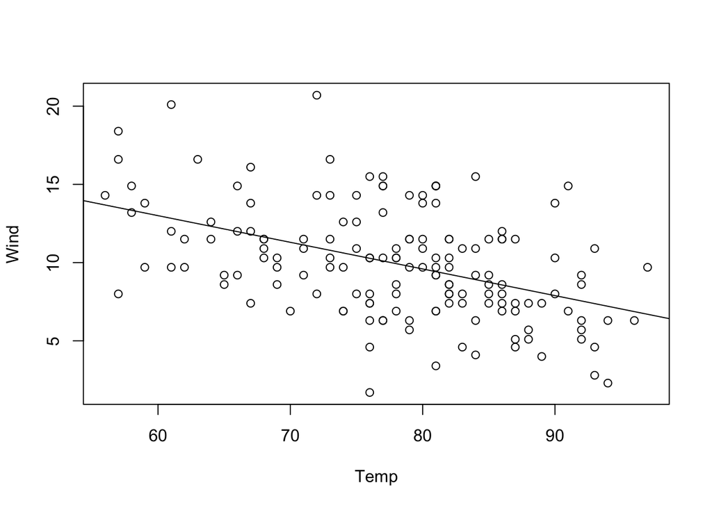

```r
plot(Wind ~ Temp, data=airquality)
abline(someNameYouMake)
```

### Part (e)

Use your model to predict the average daily average Wind speed for an outside temperature of 72 degrees F.

```r
pander(predict(someNameYouMake, data.frame(Temp=72), type="response"))
```

| 1 |
| --- |
| 10.96 |

### Part (f)

Write out an interpretation of the slope and intercept of your model. Are both meaningful for this data?

An increase of 1 degree F in the daily maximum Temperature results in a 0.17 mph decrease in the average daily average Wind speed.

When the daily maximum Temperature is 0 degrees F, the average daily average Wind speed is estimated to be 23.234 mph.

## Problem 2

Open the **mtcars** dataset in R. Fit a regression model to the data that can be used to explain average gas mileage of a vehicle (`mpg`) using the weight (`wt`) of the vehicle.

### Part (a)

Type out the mathematical equation for this regression model and label both $Y$ and $X$ in the equation.

$$\underbrace{Y_i}_\text{mpg} = \beta_0 + \beta_1\underbrace{\text{X}_1}_\text{wt} + \epsilon_i \quad \text{where} \ \epsilon_1 \sim N(0,\sigma^2)$$

### Part (b)

Fit and summarize a simple linear regression model for this data.

```r
mylm <- lm(mpg ~ wt, data=mtcars)
pander(summary(mylm))
```

|  | Estimate | Std. Error | t value | Pr(>\|t\|) |
| --- | --- | --- | --- | --- |
| **(Intercept)** | 37.29 | 1.878 | 19.86 | 8.242e-19 |
| **wt** | -5.344 | 0.5591 | -9.559 | 1.294e-10 |

Fitting linear model: mpg ~ wt

| Observations | Residual Std. Error | $R^2$ | Adjusted $R^2$ |
| --- | --- | --- | --- |
| 32 | 3.046 | 0.7528 | 0.7446 |

### Part (c)

Type out the estimated equation for this regression model using your estimates found in part (b).

$$\hat{Y}_i = 37.29 = -5.34\text{X}_i$$

### Part (d)

Plot the data and the estimated regression model.

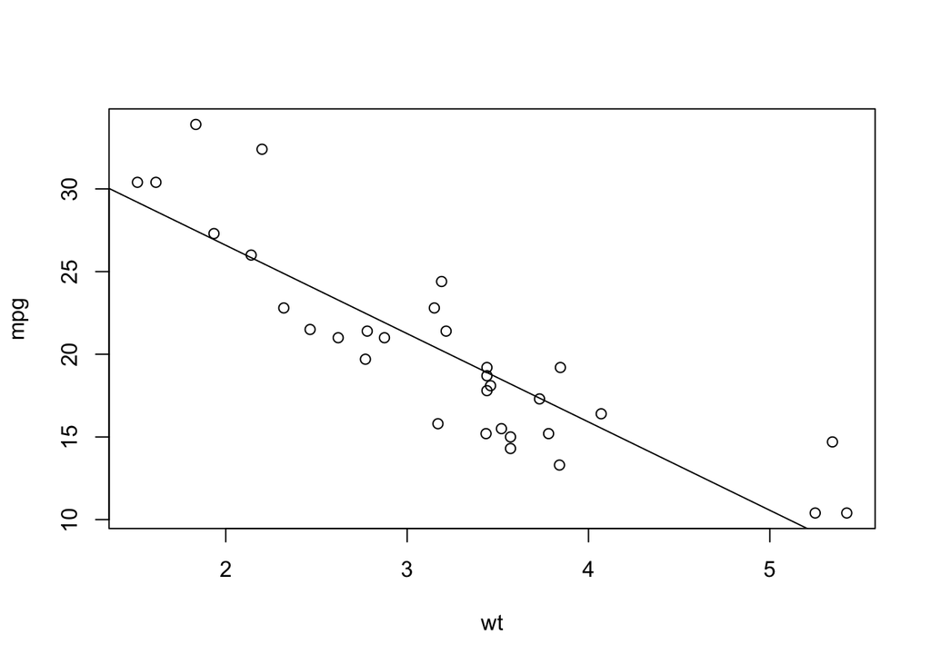

```r
plot(mpg ~ wt, data=mtcars)
abline(mylm)
```

### Part (e)

Use your model to predict the average gas mileage (mpg) for a vehicle that weighs 3,000 lbs. (Hint: ?mtcars)

```r
predict(mylm, data.frame(wt=3), type="response")
```

```
##        1
## 21.25171
```

### Part (f)

Write out an interpretation of the slope and intercept of your model. Are both meaningful for this data?

An increase of 1,000 lbs in the weight of a vehicle results in a 5.34 mpg decrease in the average gas mileage of such vehicles.

The average gas mileage of vehicles that weigh nothing (0 lbs) is estimated to be 37.29 mpg.

While the slope is significant, it only looks to be meaningful for vehicles that weigh between 2.5 thousand and 4 thousand pounds. Otherwise this regression does not seem to be a good fit for this data based on the scatterplot.

No, the intercept is not meaningful for this data because a vehicle with weight zero is not possible.

Before we can really trust the interpretation of and predictions from a regression model, there are important diagnostic checks to perform on the regression. These diagnostics are even more important to perform when p-values or confidence intervals are used as part of the analysis. In future weeks of this course, we will focus in greater detail on the technical details of regression: hypothesis tests, confidence intervals, and diagnostic checks. However, for the sake of completeness, the following problems have run through these technical details, even though we lack full understanding about them for the time being.